# Aula 2: Álgebra matricial e sobreposição de Procrustes

José Ricardo Inacio Ribeiro

Isso é um [R Markdown](http://rmarkdown.rstudio.com) Notebook depositado no [Bioforum](http://bioforum.wordpress.com). Quando executar o código, os resultados aparecerão abaixo dele!

### Translação e proporcionalização de duas configurações:

```r
# para transladar uma configuração, adicione um escalar a cada coluna...
# translade uma configuração sobre o seu centroide:
# calcule as coordenadas do centroide:
# adicionando as coordenadas em forma matricial
X1 <- matrix(c(-1, -1, 1, -1, 0, 1), byrow = T, nc = 2)
X1
```

```
##      [,1] [,2]
## [1,]   -1   -1
## [2,]    1   -1
## [3,]    0    1
```

```r
coord1 <- apply(X1, 2, mean)
coord1
```

```
## [1]  0.0000000 -0.3333333
```

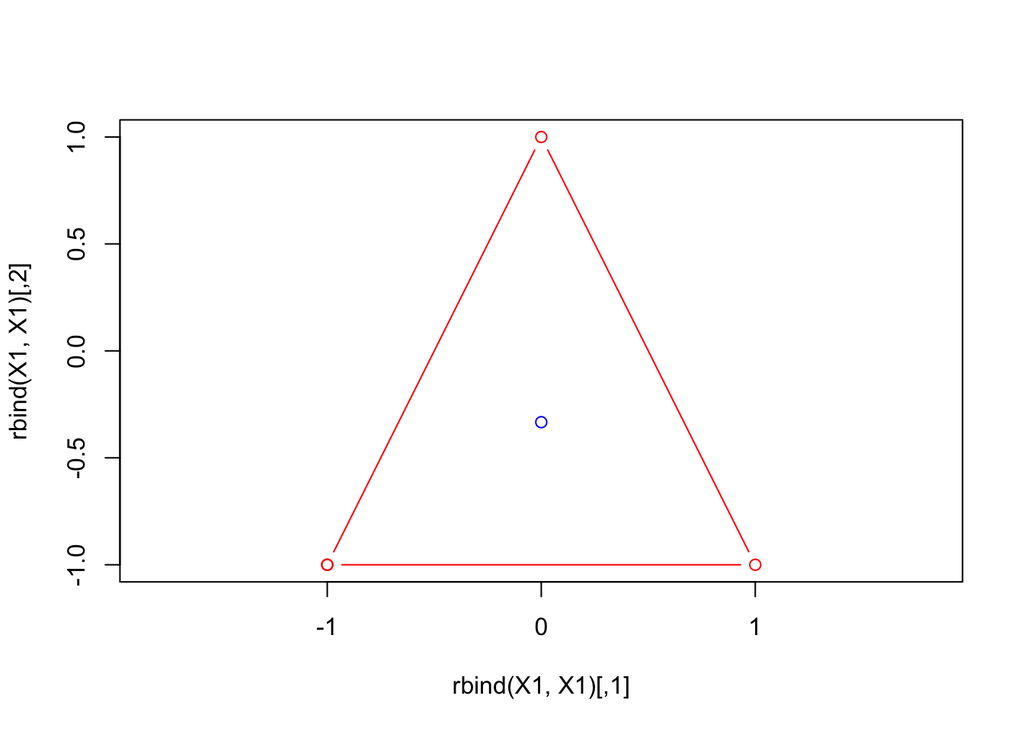

```r
# plotando o centroide com a figura:
plot(rbind(X1, X1), type = "n", asp = 1)
points(X1[c(1:3, 1),], type = "b", col = "red")
points(coord1[1], coord1[2], type = "p", col = "blue")
```

```r
X2 <- matrix(c(1.07, -1.64, 3.10, -0.72, 1.55, 0.82), byrow = T, nc = 2)
X2
```

```
##      [,1]  [,2]
## [1,] 1.07 -1.64
## [2,] 3.10 -0.72
## [3,] 1.55  0.82
```

```r
coord2 <- apply(X2, 2, mean)
coord2
```

```
## [1]  1.9066667 -0.5133333
```

```r
# remover as coordenadas do centroide de cada coordenada em uma configuração
rep(1, 3) %*% t(coord1) # multiplicação de matrizes para gerar uma matriz de subtração
```

```
##      [,1]       [,2]
## [1,]    0 -0.3333333
## [2,]    0 -0.3333333
## [3,]    0 -0.3333333
```

```r
trans1 <- X1 - rep(1, 3) %*% t(coord1)
trans1
```

```
##      [,1]       [,2]
## [1,]   -1 -0.6666667
## [2,]    1 -0.6666667
## [3,]    0  1.3333333
```

```r
trans2 <- X2 - rep(1, 3) %*% t(coord2)
trans2
```

```
##            [,1]       [,2]
## [1,] -0.8366667 -1.1266667
## [2,]  1.1933333 -0.2066667
## [3,] -0.3566667  1.3333333
```

```r
# as coordenadas do centroide agora foram ajustadas para a origem (0,0)
apply(trans1, 2, mean)
```

```
## [1]  0.000000e+00 -7.401487e-17
```

Se plotarmos as coordenadas resultantes dos cálculos acima num plano Cartesiano, temos…

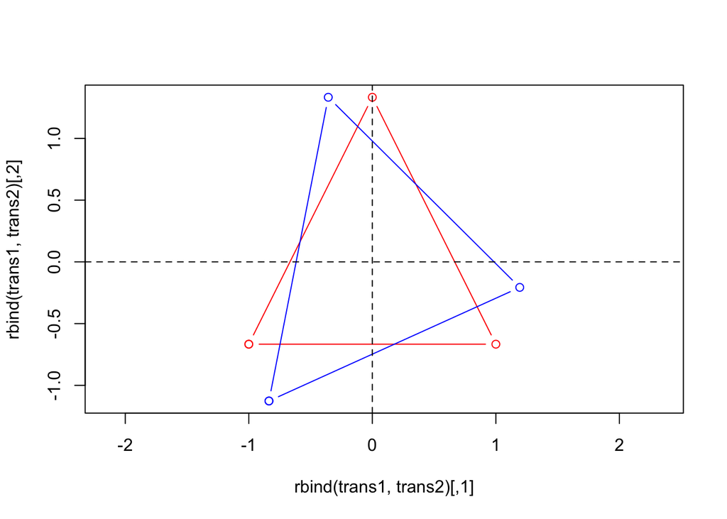

```r
#vendo as formas centradas na origem dos eixos e o efeito de posição é eliminado!
plot(rbind(trans1, trans2), type = "n", asp = 1)
points(trans1[c(1:3, 1),], type = "b", col = "red")
points(trans2[c(1:3, 1),], type = "b", col = "blue")
abline(h = 0, lty = 2)
abline(v = 0, lty = 2)
```

$\color{red}{\text{Vamos criar uma função (já vimos isso antes) para calcular as coordenadas do centroide de uma}}$ $\color{red}{\text{configuração e remover as coordenadas do centroide de cada coordenada em uma configuração:}}$

```r
tam.cente<-function(dados){
  d.med <- apply(dados, 2, mean)
  cente <- dados - rep(1, dim(dados)[1]) %*% t(d.med)
  zeca <- sqrt(sum(cente^2))
  zeca.M <- cente / zeca
  return(list(escalonado = zeca.M, tcent = zeca))
}
```

### Podemos evocar essa função sempre que quisermos usar…

```r
#source('~/Dropbox/aulas/Morfogeo/morfo_aulas/tamcente.R')
```

### Proporcionalização das configurações:

```r
#Podemos escalonar pela linha de base ou pelo tamanho do centroide...
#Para escalonar uma configuração, nós vamos dividir ou multiplicar todas as coordenadas pelo escalar apropriado: no caso, o tamanho do centroide!
# O tamanho do centroide é a raiz quadrada da soma das distâncias quadradas das coordenadas ao centroide:
# Por isso, filtramos o tamanho também!
transa1 <- tam.cente(X1)
transa1
```

```
## $escalonado
##          [,1]       [,2]
## [1,] -0.46291 -0.3086067
## [2,]  0.46291 -0.3086067
## [3,]  0.00000  0.6172134
##
## $tcent
## [1] 2.160247
```

```r
transa2 <- tam.cente(X2)
transa2
```

```
## $escalonado
##            [,1]        [,2]
## [1,] -0.3620227 -0.48750462
## [2,]  0.5163510 -0.08942392
## [3,] -0.1543284  0.57692854
##
## $tcent
## [1] 2.311089
```

```r
# another way to do that is to center the configuration with scale
esc1 <- scale(X1, scale = F)
esc1 / transa1$tcent
```

```
##          [,1]       [,2]
## [1,] -0.46291 -0.3086067
## [2,]  0.46291 -0.3086067
## [3,]  0.00000  0.6172134
## attr(,"scaled:center")
## [1]  0.0000000 -0.3333333
```

```r
esc2 <- scale(X2, scale = F)
esc2 / transa2$tcent
```

```
##            [,1]        [,2]
## [1,] -0.3620227 -0.48750462
## [2,]  0.5163510 -0.08942392
## [3,] -0.1543284  0.57692854
## attr(,"scaled:center")
## [1]  1.9066667 -0.5133333
```

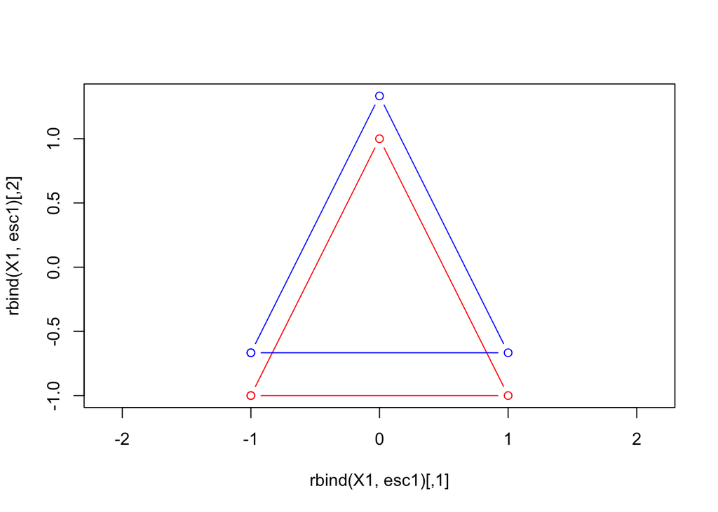

```r
#vendo as formas centradas com escala
plot(rbind(X1, esc1), type = "n", asp = 1)
points(X1[c(1:3, 1),], type = "b", col = "red")
points(esc1[c(1:3, 1),], type = "b", col = "blue")
```

### **_______exercício 3________:**

1. Faça o mesmo para a configuração X2 e crie uma função que escalone para uma unidade de tamanho de centroide

### **_______exercício 4________:**

Vamos iterativamente rotacionar um triângulo sobre o outro e checar os valores de distância parcial de Procrustes?

```r
# Vamos buscar as formas já proporcionalizadas e transladadas...
#transa1; transa2
tudo <- array(NA, dim = c(3, 2, 2))
tudo[,,1] <- transa1$escalonado
tudo[,,2] <- transa2$escalonado

# Definimos Qm que deve ser minimizado:
D <- dist(t(matrix(tudo, 3 * 2, 2)))
Q1 <- sum(as.numeric(D))
dif <- Q1
dif
```

```
## [1] 0.3442672
```

```r
tudo
```

```
## , , 1
##
##          [,1]       [,2]
## [1,] -0.46291 -0.3086067
## [2,]  0.46291 -0.3086067
## [3,]  0.00000  0.6172134
##
## , , 2
##
##            [,1]        [,2]
## [1,] -0.3620227 -0.48750462
## [2,]  0.5163510 -0.08942392
## [3,] -0.1543284  0.57692854
```

```r
# O ângulo deve ser em rad, não em graus
#ang <- teta * 180 / pi #lembre-se que para converter de rad para graus
teta <- seq(from = 0.01, to = 1.99 * pi, by = 0.01) #fazendo a sequência de zero até 2pi radianos
iter <- 1
tempo.arr <- array(NA, dim = c(3, 2, 2)) #para colocar as configurações rotacionadas
tempo.arr[,,1] <- tudo[,,1]

while(abs(dif) > 0.001){
  # Matriz de rotação, com um ângulo teta (em graus), que tenta encontrar a posição no espaço de pré-forma em que as   fibras das duas configurações estão à menor distância possível:
  H <- matrix(c(cos(teta[iter]), -sin(teta[iter]), sin(teta[iter]), cos(teta[iter])), byrow = T, ncol = 2)
  tempo <- tudo[,,2] %*% H

  # Cálculo de uma soma de quadrados e sua divisão pelo número de graus de liberdade apropriado (quadrado médio ou     variância):
  # Definimos Qm que deve ser minimizado:
  tempo.arr[,,2] <- tempo
  D <- dist(t(matrix(tempo.arr, 3 * 2, 2)))
  Q2 <- sum(as.numeric(D))
  dif <- Q1 - Q2
  Q1 <- Q2
  iter <- iter + 1
}
Q1 # distância de Procrustes
```

```
## [1] 0.0895618
```

```r
ang <- teta[iter] * 180 / pi #lembre-se que para converter de rad para graus
ang # ângulo de rotação que minimiza as distâncias quadráticas
```

```
## [1] 20.05352
```

```r
tudo <- tempo.arr
tudo #com a forma dois rotacionada a fim de se obter a menor distância de Procrustes
```

```
## , , 1
##
##          [,1]       [,2]
## [1,] -0.46291 -0.3086067
## [2,]  0.46291 -0.3086067
## [3,]  0.00000  0.6172134
##
## , , 2
##
##             [,1]       [,2]
## [1,] -0.50387505 -0.3388674
## [2,]  0.45697063 -0.2565012
## [3,]  0.04690442  0.5953686
```

### **_______exercício 5________:**

Plote a configuração rotacionada com a configuração de referência no *espaço de pré-forma* no mesmo gráfico.

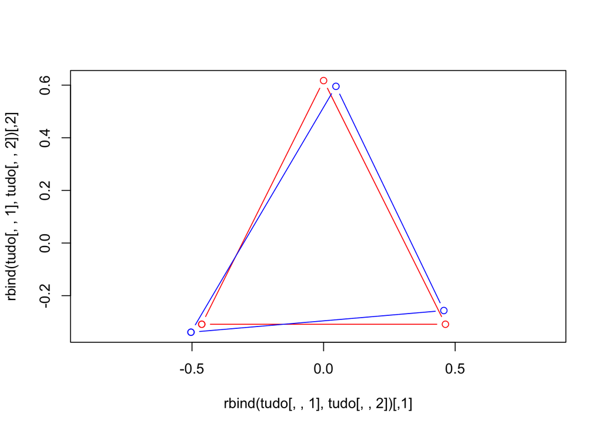

```r
plot(rbind(tudo[,,1], tudo[,,2]), type = "n", asp = 1)
points(tudo[c(1:3, 1),,1], type = "b", col = "red")
points(tudo[c(1:3, 1),,2], type = "b", col = "blue")
```

### Rotação para mais de duas configurações: devemos definir a quantidade *Qm* que deve ser minimizada, isto é, a soma das distâncias de Procrustes entre as configurações!

```r
p <- dim(X1)[1] #número de linhas
k <- dim(X1)[2] #número de colunas
tempo <- todos <- array(NA, dim = c(p, k, 3))
todos[,,1] <- transa1$escalonado
todos[,,2] <- transa2$escalonado
todos[,,3] <- transa1$escalonado

p <- dim(todos)[1] #número de linhas
k <- dim(todos)[2] #número de colunas
n <- dim(todos)[3] #número de configurações


# Definimos Qm que deve ser minimizado:
Qm1 <- dist(t(matrix(todos, k * p, n)))
Qm1
```

```
##           1         2
## 2 0.3442672
## 3 0.0000000 0.3442672
```

```r
Q <- sum(Qm1)
Q
```

```
## [1] 0.6885343
```

```r
# Looping com a função while:
iter <- 0
while(abs(Q) > 0.00001){
  for(i in 1:n){
    M <- apply(todos[,,-i], c(1,2), mean) #definimos a forma média
    #ignorando a configuração que irá ser rotacionada...
    k <- ncol(todos[,,i])
    sv <- svd(t(M) %*% todos[,,i]) #de acordo com Gower(1970)
    U <- sv$v
    V <- sv$u
    Delta <- sv$d
    sig <- sign(det(t(M) %*% todos[,,i]))
    Delta[k] <- sig * abs(Delta[k])
    V[,k] <- sig * V[,k]
    Gam <- U %*% t(V)
    beta <- sum(Delta)
    Mp1 <- beta * todos[,,i] %*% Gam
    tempo[,,i] <- Mp1
  }
  Qm2 <- dist(t(matrix(Mp1, k * p, n)))
  Q <- sum(Qm1) - sum(Qm2)
  Qm1 <- Qm2
  iter <- iter + 1
  todos <- tempo
}
```

Plotando a configuração rotacionada com aquela no espaço de pré-forma no mesmo gráfico:

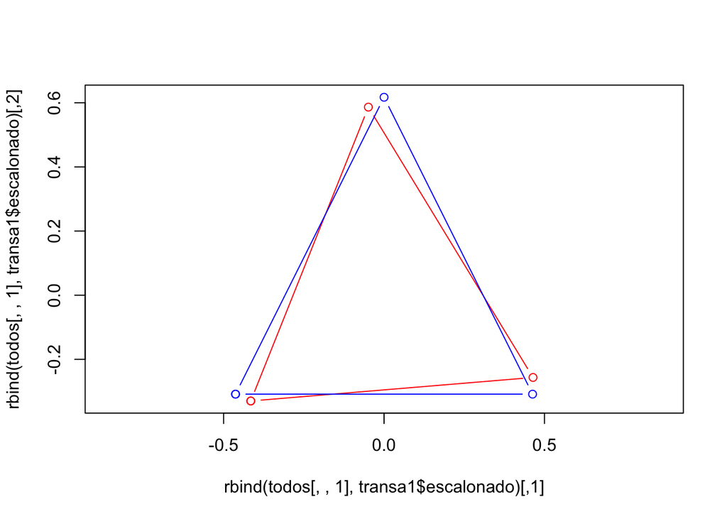

```r
plot(rbind(todos[,,1], transa1$escalonado), type = "n", asp = 1)
points(todos[c(1:3, 1),,1], type = "b", col = "red")
points(transa1$escalonado[c(1:3, 1),], type = "b", col = "blue")
```

### **_______exercício 6________:**

Plotar *TODAS* configuração rotacionadas com aquela no espaço de pré-forma no mesmo gráfico: